# SGG - How do CPR taxa do?

André Soares

8 January 2018

## 1 - Main CPR phyla across the dataset

So, as we know from before, although Proteobacteria dominate this dataset, a significant portion of all profiles is taken up by either Omnitrophica or Parcubacteria. Also, in general, these make up quite the proportion of all classified SVs:

```r
sv.phyl.p<-as.data.frame(table(tax_table(ps.b.r)[, "Phylum"], exclude = NULL))
sv.phyl.p.ord <- sv.phyl.p[order(-sv.phyl.p$Freq),]
head(sv.phyl.p.ord, n=10)
```

```
##                        Var1  Freq
## 59           Proteobacteria 20296
## 53            Parcubacteria 10064
## 52             Omnitrophica  6314
## 77                     <NA>  6006
## 72 Woesearchaeota_(DHVEG-6)  2592
## 10            Bacteroidetes  2513
## 18              Chloroflexi  2428
## 31               Firmicutes  1644
## 4            Actinobacteria  1442
## 48           Microgenomates  1394
```

```r
(10064+6314)/sum(sv.phyl.p.ord$Freq)
```

```
## [1] 0.2340717
```

So around 23% of the dataset is CPR. But given how novel these phyla are, classification is still lacking at deeper taxonomic levels.

```r
ps.b.r.cpr = subset_taxa(ps.b.r, Phylum %in% c("Omnitrophica", "Parcubacteria"))
ps.b.r.cpr.c<-as.data.frame(table(tax_table(ps.b.r.cpr)[, "Class"], exclude = NULL))
ps.b.r.cpr.c.ord <- ps.b.r.cpr.c[order(-ps.b.r.cpr.c$Freq),]
head(ps.b.r.cpr.c.ord, n=10)
```

```
##                            Var1  Freq
## 16                         <NA> 11198
## 2       Candidatus_Azambacteria   852
## 6  Candidatus_Jorgensenbacteria   845
## 8  Candidatus_Magasanikbacteria   845
## 10    Candidatus_Nomurabacteria   569
## 9      Candidatus_Moranbacteria   447
## 4     Candidatus_Falkowbacteria   435
## 14  Omnitrophica_Incertae_Sedis   426
## 12     Candidatus_Wolfebacteria   202
## 1      Candidatus_Adlerbacteria   139
```

```r
11198/sum(ps.b.r.cpr.c.ord$Freq)
```

```
## [1] 0.6837221
```

Even at class level, ~68% of Omnitrophica and Parcubacteria SVs are unclassified. Let’s take a closer look at their distribution though.

```r
ps.b.r.cpr.glom <- tax_glom(ps.b.r.cpr, taxrank = 'Phylum', NArm = FALSE)
ps.b.r.cpr.glom.psdf <- data.table(psmelt(ps.b.r.cpr.glom))
ps.b.r.cpr.glom.psdf$Phylum <- as.character(ps.b.r.cpr.glom.psdf$Phylum)
ps.b.r.cpr.glom.psdf.plot<-ggplot(ps.b.r.cpr.glom.psdf[Abundance > 0],
                                    aes(x = Site.name, y = Abundance/3, fill = Phylum)) +
  facet_grid(Month~.) +
  geom_bar(stat = "identity") +
  theme(axis.title.x = element_blank(),
        axis.text.x = element_text(angle = 45, hjust = 1)) +
  guides(fill = guide_legend(keywidth = 1, keyheight = 1)) +
  ylab("Relative Abundance\n")
```

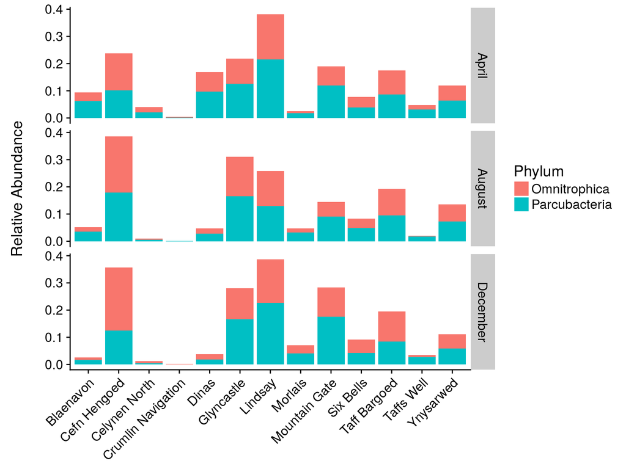

```r
ps.b.r.cpr.glom.psdf.plot
```

Are these related to time of sampling for example? CPR phyla have been described to mainly be composed of ultrasmall bacteria frequently posed to be symbiotic to larger bacteria. Is there evidence for this in this dataset?

```r
ps.b.r.cpr.glom.temp <- tax_glom(ps.b.r.cpr, taxrank = 'Class', NArm = FALSE)
ps.b.r.cpr.glom.psdf.temp <- data.table(psmelt(ps.b.r.cpr.glom.temp))
ps.b.r.cpr.glom.psdf.temp$Class<-as.character(ps.b.r.cpr.glom.psdf.temp$Class)
ps.b.r.cpr.glom.psdf.temp <- data.frame(lapply(ps.b.r.cpr.glom.psdf.temp,
                                               function(x) {gsub("Candidatus_", "Cand. ", x)}))
levels(ps.b.r.cpr.glom.psdf.temp$Class)<-c(levels(ps.b.r.cpr.glom.psdf.temp$Class),c("Unc. Omnitrophica","Unc. Parcubacteria"))
ps.b.r.cpr.glom.psdf.temp$Class[is.na(ps.b.r.cpr.glom.psdf.temp$Class) & ps.b.r.cpr.glom.psdf.temp$Phylum=="Omnitrophica"] <- "Unc. Omnitrophica"
ps.b.r.cpr.glom.psdf.temp$Class[is.na(ps.b.r.cpr.glom.psdf.temp$Class) & ps.b.r.cpr.glom.psdf.temp$Phylum=="Parcubacteria"] <- "Unc. Parcubacteria"
ps.b.r.cpr.glom.psdf.temp$Class<-as.character(ps.b.r.cpr.glom.psdf.temp$Class)
ps.b.r.cpr.glom.psdf.temp$Abundance<-as.numeric(as.character(ps.b.r.cpr.glom.psdf.temp$Abundance))
ps.b.r.cpr.glom.psdf.temp$Month = factor(ps.b.r.cpr.glom.psdf.temp$Month,
                                           levels=c("December", "August", "April"))
ps.b.r.cpr.glom.psdf.temp.f<-subset(ps.b.r.cpr.glom.psdf.temp,
                                                  Class %in% c("Unc. Omnitrophica", "Unc. Parcubacteria", "Cand. Azambacteria",
                                                               "Cand. Jorgensenbacteria","Cand. Nomurabacteria","Cand. Moranbacteria"))
ps.b.r.cpr.glom.psdf.temp.f$Class = factor(ps.b.r.cpr.glom.psdf.temp.f$Class,
                                           levels=c("Unc. Omnitrophica", "Unc. Parcubacteria", "Cand. Azambacteria",
                                                    "Cand. Jorgensenbacteria","Cand. Nomurabacteria","Cand. Moranbacteria"))
ps.b.r.cpr.glom.psdf.temp.f.plot <- ggplot(ps.b.r.cpr.glom.psdf.temp.f,
       aes(x=Month, y=Abundance, color=Site.name)) +
  geom_point(aes(fill=Site.name,
                 color=Site.name)) +
  geom_smooth(aes(group=Site.name),
              method="loess", se = FALSE) +
  facet_wrap(~Class, ncol=4)+
  theme(axis.title.y = element_blank(),
        axis.text.x = element_text(hjust=1, vjust=1, angle=25, size=8),
        axis.text.y = element_text(size=8),
        text = element_text(size=8)) +
  coord_flip() +
  scale_x_discrete(expand=c(0.05, 0.05)) +
  scale_color_manual(values = colorRampPalette(brewer.pal(12, "Paired"))(13))
```

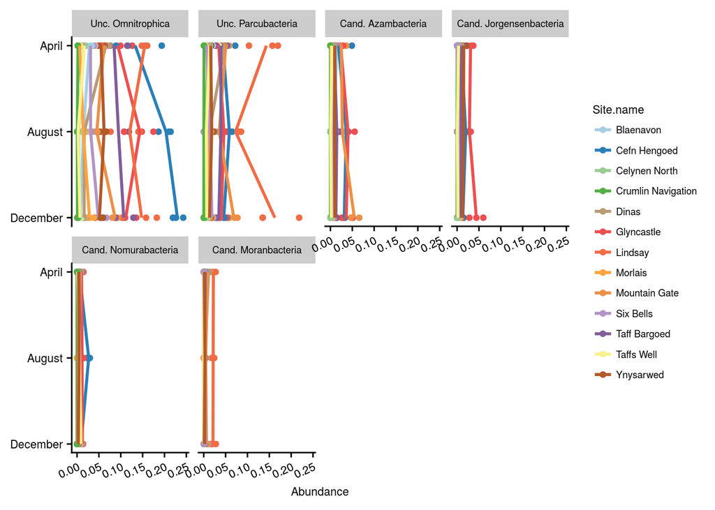

```r
ps.b.r.cpr.glom.psdf.temp.f.plot
```

So, quite interesting stuff! Phylum Omnitrophica and member of the Parcubacteria phylum (now superphylum) Falkowbacteria have been implicated as being involved in dissimilatory sulfur cycling. The first seems to reduce sulfite via the siroheme-dependent anaerobic sulfite reductase (asr), while the latter hasn’t had its sulfur cycling mechanisms completely unfolded. Both can use H, fatty acid metabolism-derived and organic C compounds as electron donors.

So, what next then? How about aligning all CPR sequences?

```r
seqs <- taxa_names(ps.b.r.cpr)
names(seqs) <- seqs
# alignment <- AlignSeqs(DNAStringSet(seqs), anchor=NA)
# writeXStringSet(alignment, filepath="/media/andre/B2F8C9A0F8C962E9/SGG_16S_analysis/SGG_16S_R/phyloseq_DataAnalysis/cpr_alignments.fasta")
cpr_alignment<-readDNAStringSet("/media/andre/B2F8C9A0F8C962E9/SGG_16S_analysis/SGG_16S_R/phyloseq_DataAnalysis/cpr_alignments.fasta")
# identical(alignment, cpr_alignment)
# tree was generated within linux with
# FastTree -gtr -nt < cpr_alignments.fasta > cpr_alignments_tree
#using Fasttree v2.1.3,
library(ape)
tree_Q = read.tree("/media/andre/B2F8C9A0F8C962E9/SGG_16S_analysis/SGG_16S_R/phyloseq_DataAnalysis/cpr_alignments_tree")
is.rooted(tree_Q)
```

```
## [1] FALSE
```

```r
##randomly root your tree -- or you could put an outgroup in and then trim it after tree is rooted
tree_Q = root(tree_Q, 1, resolve.root = T)
ps.b.r.cpr.tree<-merge_phyloseq(ps.b.r.cpr, tree_Q)
ps.b.r.cpr.tree
```

```
## phyloseq-class experiment-level object
## otu_table()   OTU Table:         [ 16378 taxa and 117 samples ]
## sample_data() Sample Data:       [ 117 samples by 80 sample variables ]
## tax_table()   Taxonomy Table:    [ 16378 taxa by 7 taxonomic ranks ]
## phy_tree()    Phylogenetic Tree: [ 16378 tips and 16377 internal nodes ]
```

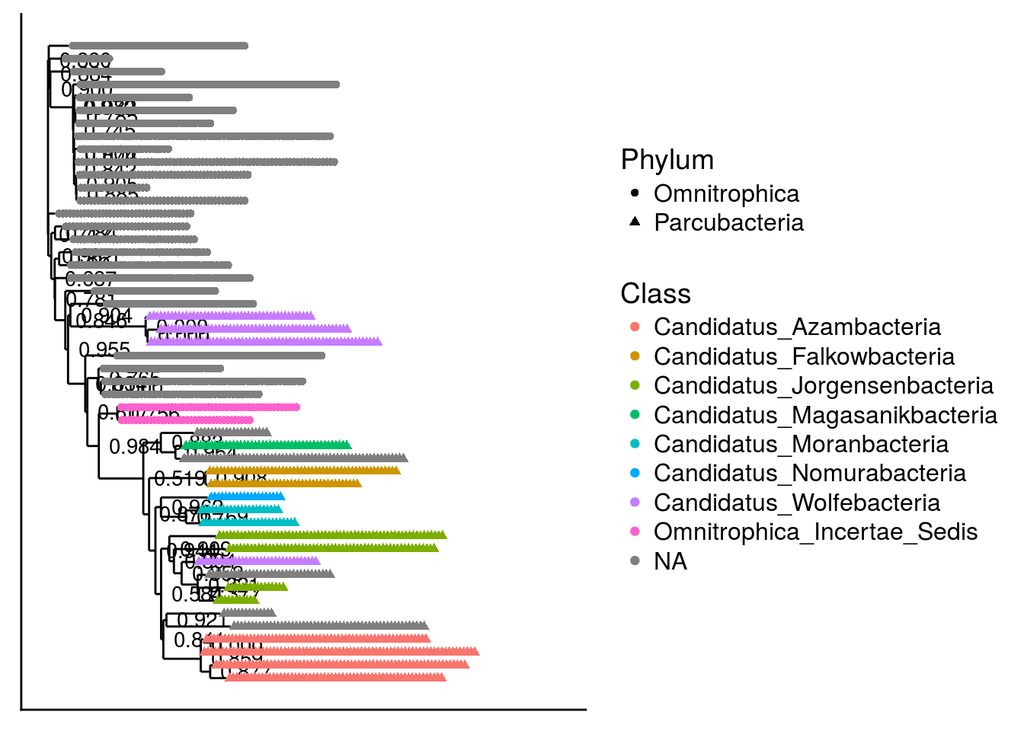

```r
Top50CPR <- names(sort(taxa_sums(ps.b.r.cpr.tree), TRUE)[1:50])
Top50CPR.ps.b.r.cpr.tree   <- prune_taxa(Top50CPR, ps.b.r.cpr.tree)
plot_tree(Top50CPR.ps.b.r.cpr.tree, ladderize=TRUE,
          color="Class", shape="Phylum")
```

Ok this is getting weird - Wolfebacteria supposedly within Omnitrophica? Get a root! Let’s do something useful!